# AB testing Marketing Campaign

```python
# Import necessary libraries
import pandas as pd
import numpy as np
import matplotlib.pyplot as plt
import seaborn as sns
from scipy import stats
import statsmodels.api as sm
from sklearn.linear_model import LinearRegression
from sklearn.metrics import r2_score, mean_squared_error
from statsmodels.tsa.seasonal import seasonal_decompose
from statsmodels.tsa.stattools import coint
import warnings
warnings.filterwarnings('ignore')
```

```python
# load the dataset
data = pd.read_csv('/Users/khushibalar/Downloads/marketing_campaign.csv')
```

```python
# data overview
data.head()
```

|  | Date | Facebook Ad Campaign | Facebook Ad Views | Facebook Ad Clicks | Facebook Ad Conversions | Cost per Facebook Ad | Facebook Click-Through Rate (Clicks / View) | Facebook Conversion Rate (Conversions / Clicks) | Facebook Cost per Click (Ad Cost / Clicks) | AdWords Ad Campaign | AdWords Ad Views | AdWords Ad Clicks | AdWords Ad Conversions | Cost per AdWords Ad | AdWords Click-Through Rate (Clicks / View) | AdWords Conversion Rate (Conversions / Click) | AdWords Cost per Click (Ad Cost / Clicks) |
| --- | --- | --- | --- | --- | --- | --- | --- | --- | --- | --- | --- | --- | --- | --- | --- | --- | --- |
| 0 | 1/1/2019 | FB_Jan19 | 2116 | 18 | 8 | $126 | 0.83% | 42.73% | $7.14 | AW_Jan19 | 4984 | 59 | 5 | $194 | 1.18% | 8.40% | $3.30 |
| 1 | 1/2/2019 | FB_Jan19 | 3106 | 36 | 12 | $104 | 1.15% | 34.04% | $2.91 | AW_Jan19 | 4022 | 71 | 6 | $75 | 1.77% | 7.80% | $1.05 |
| 2 | 1/3/2019 | FB_Jan19 | 3105 | 26 | 8 | $102 | 0.84% | 31.45% | $3.89 | AW_Jan19 | 3863 | 44 | 4 | $141 | 1.13% | 9.59% | $3.23 |
| 3 | 1/4/2019 | FB_Jan19 | 1107 | 27 | 9 | $71 | 2.45% | 34.76% | $2.62 | AW_Jan19 | 3911 | 49 | 5 | $141 | 1.26% | 11.08% | $2.86 |
| 4 | 1/5/2019 | FB_Jan19 | 1317 | 15 | 7 | $78 | 1.10% | 47.59% | $5.38 | AW_Jan19 | 4070 | 55 | 7 | $133 | 1.36% | 12.22% | $2.40 |

```python
# Display basic info to understand the data structure
data.info()
```

```
<class 'pandas.core.frame.DataFrame'>
RangeIndex: 365 entries, 0 to 364
Data columns (total 17 columns):
 #   Column                                           Non-Null Count  Dtype
---  ------                                           --------------  -----
 0   Date                                             365 non-null    object
 1   Facebook Ad Campaign                             365 non-null    object
 2   Facebook Ad Views                                365 non-null    int64
 3   Facebook Ad Clicks                               365 non-null    int64
 4   Facebook Ad Conversions                          365 non-null    int64
 5   Cost per Facebook Ad                             365 non-null    object
 6   Facebook Click-Through Rate (Clicks / View)      365 non-null    object
 7   Facebook Conversion Rate (Conversions / Clicks)  365 non-null    object
 8   Facebook Cost per Click (Ad Cost / Clicks)       365 non-null    object
 9   AdWords Ad Campaign                              365 non-null    object
 10  AdWords Ad Views                                 365 non-null    int64
 11  AdWords Ad Clicks                                365 non-null    int64
 12  AdWords Ad Conversions                           365 non-null    int64
 13  Cost per AdWords Ad                              365 non-null    object
 14  AdWords Click-Through Rate (Clicks / View)       365 non-null    object
 15  AdWords Conversion Rate (Conversions / Click)    365 non-null    object
 16  AdWords Cost per Click (Ad Cost / Clicks)        365 non-null    object
dtypes: int64(6), object(11)
memory usage: 48.6+ KB
```

```python
# rows and columns count of the dataset
data.shape
```

```
(365, 17)
```

Start Data cleaning

```python
# Define columns to clean
monetary_columns = [
    "Cost per Facebook Ad", "Facebook Cost per Click (Ad Cost / Clicks)",
    "Cost per AdWords Ad", "AdWords Cost per Click (Ad Cost / Clicks)"
]

percentage_columns = [
    "Facebook Click-Through Rate (Clicks / View)", "Facebook Conversion Rate (Conversions / Clicks)",
    "AdWords Click-Through Rate (Clicks / View)", "AdWords Conversion Rate (Conversions / Click)"
]
```

```python
# Clean monetary columns by removing "$" and converting to float
for col in monetary_columns:
    data[col] = data[col].replace('[\$,]', '', regex=True).astype(float)
```

```python
# Clean percentage columns by removing "%" and converting to float
for col in percentage_columns:
    data[col] = data[col].replace('%', '', regex=True).astype(float) / 100  # Convert to proportion
```

```python
# converting date to datetime
data['Date'] = pd.to_datetime(data['Date'])
```

```python
# Confirm the changes by displaying the data types again
data.info()
```

```
<class 'pandas.core.frame.DataFrame'>
RangeIndex: 365 entries, 0 to 364
Data columns (total 17 columns):
 #   Column                                           Non-Null Count  Dtype
---  ------                                           --------------  -----
 0   Date                                             365 non-null    datetime64[ns]
 1   Facebook Ad Campaign                             365 non-null    object
 2   Facebook Ad Views                                365 non-null    int64
 3   Facebook Ad Clicks                               365 non-null    int64
 4   Facebook Ad Conversions                          365 non-null    int64
 5   Cost per Facebook Ad                             365 non-null    float64
 6   Facebook Click-Through Rate (Clicks / View)      365 non-null    float64
 7   Facebook Conversion Rate (Conversions / Clicks)  365 non-null    float64
 8   Facebook Cost per Click (Ad Cost / Clicks)       365 non-null    float64
 9   AdWords Ad Campaign                              365 non-null    object
 10  AdWords Ad Views                                 365 non-null    int64
 11  AdWords Ad Clicks                                365 non-null    int64
 12  AdWords Ad Conversions                           365 non-null    int64
 13  Cost per AdWords Ad                              365 non-null    float64
 14  AdWords Click-Through Rate (Clicks / View)       365 non-null    float64
 15  AdWords Conversion Rate (Conversions / Click)    365 non-null    float64
 16  AdWords Cost per Click (Ad Cost / Clicks)        365 non-null    float64
dtypes: datetime64[ns](1), float64(8), int64(6), object(2)
memory usage: 48.6+ KB
```

```python
# Display the first few rows to confirm the conversion and the cleaned data structure
data.head()
```

|  | Date | Facebook Ad Campaign | Facebook Ad Views | Facebook Ad Clicks | Facebook Ad Conversions | Cost per Facebook Ad | Facebook Click-Through Rate (Clicks / View) | Facebook Conversion Rate (Conversions / Clicks) | Facebook Cost per Click (Ad Cost / Clicks) | AdWords Ad Campaign | AdWords Ad Views | AdWords Ad Clicks | AdWords Ad Conversions | Cost per AdWords Ad | AdWords Click-Through Rate (Clicks / View) | AdWords Conversion Rate (Conversions / Click) | AdWords Cost per Click (Ad Cost / Clicks) |
| --- | --- | --- | --- | --- | --- | --- | --- | --- | --- | --- | --- | --- | --- | --- | --- | --- | --- |
| 0 | 2019-01-01 | FB_Jan19 | 2116 | 18 | 8 | 126.0 | 0.000083 | 0.004273 | 7.14 | AW_Jan19 | 4984 | 59 | 5 | 194.0 | 0.000118 | 0.000840 | 3.30 |
| 1 | 2019-01-02 | FB_Jan19 | 3106 | 36 | 12 | 104.0 | 0.000115 | 0.003404 | 2.91 | AW_Jan19 | 4022 | 71 | 6 | 75.0 | 0.000177 | 0.000780 | 1.05 |
| 2 | 2019-01-03 | FB_Jan19 | 3105 | 26 | 8 | 102.0 | 0.000084 | 0.003145 | 3.89 | AW_Jan19 | 3863 | 44 | 4 | 141.0 | 0.000113 | 0.000959 | 3.23 |
| 3 | 2019-01-04 | FB_Jan19 | 1107 | 27 | 9 | 71.0 | 0.000245 | 0.003476 | 2.62 | AW_Jan19 | 3911 | 49 | 5 | 141.0 | 0.000126 | 0.001108 | 2.86 |
| 4 | 2019-01-05 | FB_Jan19 | 1317 | 15 | 7 | 78.0 | 0.000110 | 0.004759 | 5.38 | AW_Jan19 | 4070 | 55 | 7 | 133.0 | 0.000136 | 0.001222 | 2.40 |

Total Cost, Total Clicks, and Total Conversions for each platform to establish baseline metrics

```python
# Total cost
total_cost_facebook = data["Cost per Facebook Ad"].sum()
total_cost_adwords = data["Cost per AdWords Ad"].sum()
```

```python
# Total clicks
total_clicks_facebook = data["Facebook Ad Clicks"].sum()
total_clicks_adwords = data["AdWords Ad Clicks"].sum()
```

```python
# Total conversions
total_conversions_facebook = data["Facebook Ad Conversions"].sum()
total_conversions_adwords = data["AdWords Ad Conversions"].sum()
```

```python
# Create a summary dataframe for easy viewing
summary = pd.DataFrame({
    "Platform": ["Facebook", "AdWords"],
    "Total Cost": [total_cost_facebook, total_cost_adwords],
    "Total Clicks": [total_clicks_facebook, total_clicks_adwords],
    "Total Conversions": [total_conversions_facebook, total_conversions_adwords]
})
```

```python
# Display the summary
summary
```

|  | Platform | Total Cost | Total Clicks | Total Conversions |
| --- | --- | --- | --- | --- |
| 0 | Facebook | 32040.0 | 16078 | 4286 |
| 1 | AdWords | 49266.0 | 22040 | 2183 |

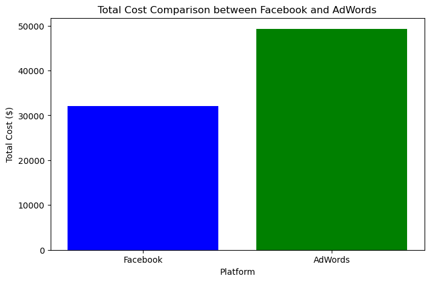

```python
# Total Cost Comparison Between Facebook And AdWords
plt.figure(figsize=(8, 5))
plt.bar(summary['Platform'], summary['Total Cost'], color=['blue', 'green'])
plt.title('Total Cost Comparison between Facebook and AdWords')
plt.ylabel('Total Cost ($)')
plt.xlabel('Platform')
plt.show()
```

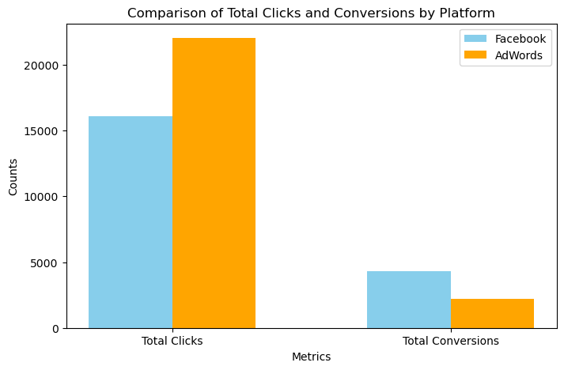

```python
# Define data for the grouped bar chart
metrics = ["Total Clicks", "Total Conversions"]
facebook_values = [summary.loc[0, "Total Clicks"], summary.loc[0, "Total Conversions"]]
adwords_values = [summary.loc[1, "Total Clicks"], summary.loc[1, "Total Conversions"]]

# Set up the bar positions and width
x = np.arange(len(metrics))
width = 0.3

# Plot bars for each platform
plt.figure(figsize=(8, 5))
plt.bar(x - width/2, facebook_values, width, label='Facebook', color='skyblue')
plt.bar(x + width/2, adwords_values, width, label='AdWords', color='orange')

# Add labels and title
plt.xticks(x, metrics)
plt.xlabel("Metrics")
plt.ylabel("Counts")
plt.title("Comparison of Total Clicks and Conversions by Platform")
plt.legend()
plt.show()
```

`Relationship between Clicks and Conversions

```python
# Calculate the correlation between clicks and conversions for Facebook and AdWords
correlation_facebook = data["Facebook Ad Clicks"].corr(data["Facebook Ad Conversions"])
correlation_adwords = data["AdWords Ad Clicks"].corr(data["AdWords Ad Conversions"])
```

```python
# Store results in a dictionary for easy display
correlation_results = {
    "Platform": ["Facebook", "AdWords"],
    "Clicks-Conversions Correlation": [correlation_facebook, correlation_adwords]
}
```

```python
# Convert to DataFrame for display
correlation_df = pd.DataFrame(correlation_results)
correlation_df
```

|  | Platform | Clicks-Conversions Correlation |
| --- | --- | --- |
| 0 | Facebook | 0.873775 |
| 1 | AdWords | 0.447993 |

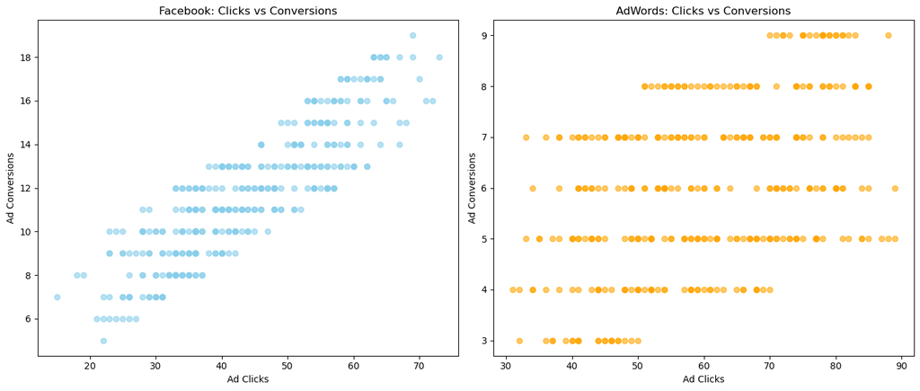

```python
# Create scatter plots to visualize the relationship between clicks and conversions for each platform

# Set up the figure
plt.figure(figsize=(14, 6))

# Facebook scatter plot
plt.subplot(1, 2, 1)
plt.scatter(data["Facebook Ad Clicks"], data["Facebook Ad Conversions"], color="skyblue", alpha=0.6)
plt.title("Facebook: Clicks vs Conversions")
plt.xlabel("Ad Clicks")
plt.ylabel("Ad Conversions")

# AdWords scatter plot
plt.subplot(1, 2, 2)
plt.scatter(data["AdWords Ad Clicks"], data["AdWords Ad Conversions"], color="orange", alpha=0.6)
plt.title("AdWords: Clicks vs Conversions")
plt.xlabel("Ad Clicks")
plt.ylabel("Ad Conversions")

plt.tight_layout()
plt.show()
```

Analyze high-low-conversion days using Mean and Standard Deviation Method

```python
# Calculate mean and standard deviation for conversions on each platform
facebook_mean = data["Facebook Ad Conversions"].mean()
facebook_std = data["Facebook Ad Conversions"].std()
adwords_mean = data["AdWords Ad Conversions"].mean()
adwords_std = data["AdWords Ad Conversions"].std()

# Define thresholds for high and low conversion days
facebook_high_threshold = facebook_mean + facebook_std
facebook_low_threshold = facebook_mean - facebook_std
adwords_high_threshold = adwords_mean + adwords_std
adwords_low_threshold = adwords_mean - adwords_std

# Create new columns categorizing days based on thresholds
def label_conversion_category(conversion, high_threshold, low_threshold):
    if conversion > high_threshold:
        return 'High-Conversion Day'
    elif conversion < low_threshold:
        return 'Low-Conversion Day'
    else:
        return 'Average Day'

data["Facebook Conversion Category"] = data["Facebook Ad Conversions"].apply(
    label_conversion_category, args=(facebook_high_threshold, facebook_low_threshold))
data["AdWords Conversion Category"] = data["AdWords Ad Conversions"].apply(
    label_conversion_category, args=(adwords_high_threshold, adwords_low_threshold))

# Display a sample of the data to confirm the new labels
data[["Date", "Facebook Ad Conversions", "Facebook Conversion Category",
      "AdWords Ad Conversions", "AdWords Conversion Category"]].head()
```

|  | Date | Facebook Ad Conversions | Facebook Conversion Category | AdWords Ad Conversions | AdWords Conversion Category |
| --- | --- | --- | --- | --- | --- |
| 0 | 2019-01-01 | 8 | Low-Conversion Day | 5 | Average Day |
| 1 | 2019-01-02 | 12 | Average Day | 6 | Average Day |
| 2 | 2019-01-03 | 8 | Low-Conversion Day | 4 | Low-Conversion Day |
| 3 | 2019-01-04 | 9 | Average Day | 5 | Average Day |
| 4 | 2019-01-05 | 7 | Low-Conversion Day | 7 | Average Day |

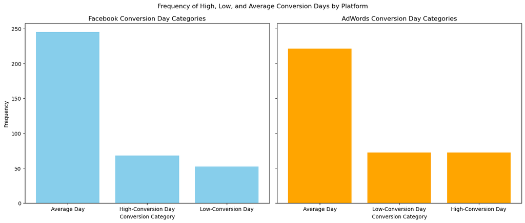

```python
# Visualize the frequency of each conversion category for both platforms

# Count the frequency of each conversion category for Facebook and AdWords
facebook_conversion_counts = data["Facebook Conversion Category"].value_counts()
adwords_conversion_counts = data["AdWords Conversion Category"].value_counts()

# Set up the plot
fig, axes = plt.subplots(1, 2, figsize=(14, 6), sharey=True)

# Plot for Facebook Conversion Categories
axes[0].bar(facebook_conversion_counts.index, facebook_conversion_counts.values, color='skyblue')
axes[0].set_title("Facebook Conversion Day Categories")
axes[0].set_xlabel("Conversion Category")
axes[0].set_ylabel("Frequency")

# Plot for AdWords Conversion Categories
axes[1].bar(adwords_conversion_counts.index, adwords_conversion_counts.values, color='orange')
axes[1].set_title("AdWords Conversion Day Categories")
axes[1].set_xlabel("Conversion Category")

plt.suptitle("Frequency of High, Low, and Average Conversion Days by Platform")
plt.tight_layout()
plt.show()
```

Hypothesis Testing

To test for significant differences in conversion rates between Facebook and AdWords, we can use a two-sample t-test or a proportion test. Here’s the approach:

Steps:

Calculate Conversion Rates: For each platform, calculate the conversion rate as the total conversions divided by total clicks.

Formulate Hypotheses: Null Hypothesis (H₀): There is no difference in conversion rates between Facebook and AdWords.

Alternative Hypothesis (H₁): There is a significant difference in conversion rates between Facebook and AdWords.

Run the Statistical Test: Use a two-sample proportion z-test to determine if the observed difference is statistically significant.

```python
from statsmodels.stats.proportion import proportions_ztest

# Calculate total conversions and clicks for each platform
facebook_total_conversions = data["Facebook Ad Conversions"].sum()
facebook_total_clicks = data["Facebook Ad Clicks"].sum()
adwords_total_conversions = data["AdWords Ad Conversions"].sum()
adwords_total_clicks = data["AdWords Ad Clicks"].sum()

# Conversion rates
facebook_conversion_rate = facebook_total_conversions / facebook_total_clicks
adwords_conversion_rate = adwords_total_conversions / adwords_total_clicks

# Run the two-sample proportion z-test
counts = [facebook_total_conversions, adwords_total_conversions]
nobs = [facebook_total_clicks, adwords_total_clicks]
z_stat, p_value = proportions_ztest(counts, nobs)

# Store and display results
hypothesis_test_results = {
    "Facebook Conversion Rate": facebook_conversion_rate,
    "AdWords Conversion Rate": adwords_conversion_rate,
    "Z-Statistic": z_stat,
    "p-value": p_value
}
hypothesis_test_results
```

```
{'Facebook Conversion Rate': 0.26657544470705313,
 'AdWords Conversion Rate': 0.09904718693284936,
 'Z-Statistic': 43.03049682241507,
 'p-value': 0.0}
```

Interpretation:

With a very low p-value (close to 0), we can reject the null hypothesis, suggesting a statistically significant difference in conversion rates between Facebook and AdWords. Facebook appears to have a significantly higher conversion rate compared to AdWords.

Run a hypothesis test on click-through rates (CTR) to determine if there’s a statistically significant difference in the click performance between Facebook and AdWords.

Set up Hypotheses:

Null Hypothesis (H₀): There is no difference in click-through rates between Facebook and AdWords.

Alternative Hypothesis (H₁): There is a significant difference in click-through rates between Facebook and AdWords.

Perform a Two-Sample Proportion Z-Test to see if the difference in CTRs is statistically significant.

```python
# Calculate total views for each platform
facebook_total_views = data["Facebook Ad Views"].sum()
adwords_total_views = data["AdWords Ad Views"].sum()

# Calculate click-through rates (CTR)
facebook_ctr = facebook_total_clicks / facebook_total_views
adwords_ctr = adwords_total_clicks / adwords_total_views

# Run the two-sample proportion z-test for CTR
ctr_counts = [facebook_total_clicks, adwords_total_clicks]
ctr_nobs = [facebook_total_views, adwords_total_views]
ctr_z_stat, ctr_p_value = proportions_ztest(ctr_counts, ctr_nobs)

# Display results
ctr_test_results = {
    "Facebook CTR": facebook_ctr,
    "AdWords CTR": adwords_ctr,
    "Z-Statistic": ctr_z_stat,
    "p-value": ctr_p_value
}
ctr_test_results
```

```
{'Facebook CTR': 0.020209003175018163,
 'AdWords CTR': 0.012800728549632153,
 'Z-Statistic': 44.7504324903407,
 'p-value': 0.0}
```

Interpretation:

The very low p-value (close to 0) suggests a statistically significant difference in CTR between Facebook and AdWords, with Facebook achieving a higher click-through rate than AdWords.

Regression Analysis

What will happen when I do go with the Facebook Ad? How many facebook ad conversions can I expect given a certain number of facebook ad clicks?

```python
# independent variable
X = data[['Facebook Ad Clicks']]

# dependent variable
y = data[['Facebook Ad Conversions']]

# initializing and fitting Linear Regression model
reg_model = LinearRegression()
reg_model.fit(X,y)
prediction = reg_model.predict(X)

# model evaluation
r2 = r2_score(y, prediction)*100
mse = mean_squared_error(y, prediction)
print('Accuracy (R2 Score):',round(r2,2),'%')
print('Mean Squared Error:', round(mse,2))
```

```
Accuracy (R2 Score): 76.35 %
Mean Squared Error: 2.02
```

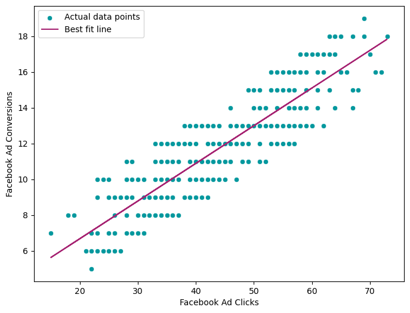

```python
plt.figure(figsize=(8,6))
sns.scatterplot(x = data['Facebook Ad Clicks'],y = data['Facebook Ad Conversions'], color = '#03989E', label = 'Actual data points')
plt.plot(data['Facebook Ad Clicks'], prediction, color = '#A62372', label = 'Best fit line')
plt.legend()
plt.show()
```

```python
print(f'For {50} Clicks, Expected Conversion : {round(reg_model.predict([[50]])[0][0],2)}')
print(f'For {80} Clicks, Expected Conversion : {round(reg_model.predict([[80]])[0][0],2)}')
```

```
For 50 Clicks, Expected Conversion : 13.0
For 80 Clicks, Expected Conversion : 19.31
```

Analyzing Facebook Campaign metrics over time.

```python
# filtering for facebook campaign
data = data[['Date','Facebook Ad Views',
       'Facebook Ad Clicks', 'Facebook Ad Conversions', 'Cost per Facebook Ad',
       'Facebook Click-Through Rate (Clicks / View)',
       'Facebook Conversion Rate (Conversions / Clicks)',
       'Facebook Cost per Click (Ad Cost / Clicks)']]

data.head()
```

|  | Date | Facebook Ad Views | Facebook Ad Clicks | Facebook Ad Conversions | Cost per Facebook Ad | Facebook Click-Through Rate (Clicks / View) | Facebook Conversion Rate (Conversions / Clicks) | Facebook Cost per Click (Ad Cost / Clicks) |
| --- | --- | --- | --- | --- | --- | --- | --- | --- |
| 0 | 2019-01-01 | 2116 | 18 | 8 | 126.0 | 0.000083 | 0.004273 | 7.14 |
| 1 | 2019-01-02 | 3106 | 36 | 12 | 104.0 | 0.000115 | 0.003404 | 2.91 |
| 2 | 2019-01-03 | 3105 | 26 | 8 | 102.0 | 0.000084 | 0.003145 | 3.89 |
| 3 | 2019-01-04 | 1107 | 27 | 9 | 71.0 | 0.000245 | 0.003476 | 2.62 |
| 4 | 2019-01-05 | 1317 | 15 | 7 | 78.0 | 0.000110 | 0.004759 | 5.38 |

At what times of the month or days of the week do we observe the conversions?

```python
# extracting month and week day from the date column
data['month'] = data['Date'].dt.month
data['week'] = data['Date'].dt.weekday
```

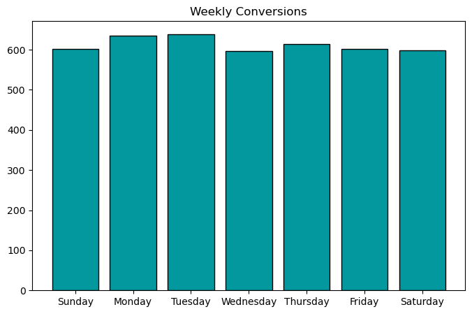

```python
plt.figure(figsize=(8,5))
plt.title('Weekly Conversions')
weekly_conversion = data.groupby('week')[['Facebook Ad Conversions']].sum()
week_names= ['Sunday','Monday','Tuesday','Wednesday','Thursday','Friday','Saturday']
plt.bar(week_names, weekly_conversion['Facebook Ad Conversions'], color = '#03989E', edgecolor = 'k')
plt.show()
```

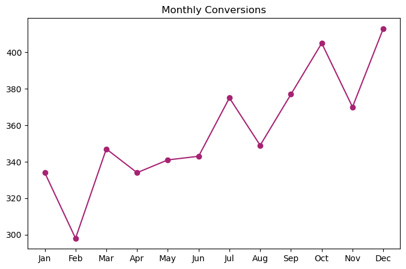

```python
plt.figure(figsize=(8,5))
plt.title('Monthly Conversions')
monthly_conversion = data.groupby('month')[['Facebook Ad Conversions']].sum()
month_names = ['Jan','Feb','Mar','Apr','May','Jun','Jul','Aug','Sep','Oct','Nov','Dec']
plt.plot(month_names, monthly_conversion['Facebook Ad Conversions'],'-o', color = '#A62372')
plt.show()
```

How does the Cost Per Conversion (CPC) trend over time?

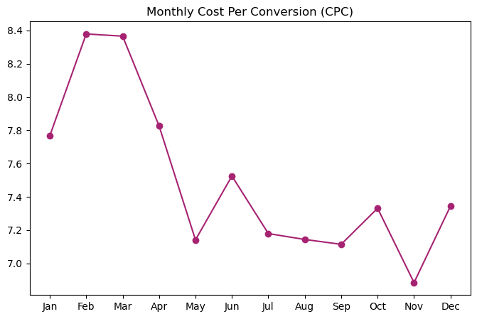

```python
plt.figure(figsize=(8,5))
plt.title('Monthly Cost Per Conversion (CPC)')
monthly_data = data.groupby('month')[['Facebook Ad Conversions','Cost per Facebook Ad']].sum()
monthly_data['Cost per Conversion'] = monthly_data['Cost per Facebook Ad']/monthly_data['Facebook Ad Conversions']
plt.plot(month_names, monthly_data['Cost per Conversion'],'-o', color = '#A62372')
plt.show()
```

Is there a long-term equilibrium relationship between advertising spend and conversion rates that suggests a stable, proportional impact of budget changes on conversions over time?

```python
score, p_value, _ = coint(data['Cost per Facebook Ad'], data['Facebook Ad Conversions'])
print('Cointegration test score:', score)
print('P-value:', p_value)
if p_value < 0.05:
    print("\np-value is less than significance value, Reject the null hypothesis")
else:
    print("\np-value is greater than significance value, Accept the null hypothesis")
```

```
Cointegration test score: -14.755428385103226
P-value: 2.1337375979060546e-26

p-value is less than significance value, Reject the null hypothesis
```

- Since the p-value is significantly lower than the chosen significance level, we reject the null hypothesis. This indicates that there is a long-term equilibrium relationship between advertising spend (cost) and conversions.
- Businesses can use this understanding of the stable relationship between cost and conversions to optimize their advertising strategies. By investing in campaigns that demonstrate a strong return on investment (ROI) and adjusting spending based on performance, companies can maximize conversions while minimizing costs.

```python
data.to_csv('AB testing Marketing Campaign.csv', index=False)
```